# Simple outputs from many matrices

2018-02-06

This example produces some basic output such as the population growth rate ($\lambda$) and damping ratio (Caswell 2001) for a subset of species and populations given some selection criteria.

```r
x<-Rcompadre::subsetDB(comadre, MatrixComposite == "Mean" &
                         Class == "Actinopterygii" &
                         StudyDuration >= 3 &
                         MatrixDimension > 3)
```

The object `x` is now a version of the `comadre` database object that contains only the matrices that match the search criteria.

These matrices can now be analyzed by applying functions in a loop, or by using `lapply`.

For example, to calculate population growth rate and damping ratio for the subset of matrices, first create an empty `data.frame` to accommodate the output

```r
output <- data.frame(lambdas = rep(NA, length(x$mat)),
                     damps = rep(NA, length(x$mat)))
```

and then use the functions in `popbio` package to derive demographic output (the user may need to install the package first).

```r
library(popbio)
```

```r
for (i in 1:length(x$mat)){
    output$lambdas[i] <- Re(eigen(x$mat[[i]]$matA)$value)[1]
    output$damps[i] <- damping.ratio(x$mat[[i]]$matA)
}
```

To examine the output:

```r
output
```

```
>      lambdas    damps
> 1  1.5061504 1.303947
> 2  1.3331871 1.242002
> 3  0.9704512 1.468910
> 4  1.0798558 1.326919
> 5  0.9529318 1.127114
> 6  1.0854466 1.146005
> 7  0.9091956 1.031997
> 8  0.9027406 1.027850
> 9  0.9140835 1.035914
> 10 0.9999592 1.005268
> 11 1.1102061 1.310725
> 12 1.3618336 1.293028
> 13 1.2283756 1.380559
> 14 1.1321531 1.288657
```

These parameters are presented in the same order as the `metadata` so we could also add the species name to this `data.frame`:

```r
data.frame(Species = x$metadata$SpeciesAccepted,output)
```

```
>                              Species   lambdas    damps
> 1               Ammocrypta_pellucida 1.5061504 1.303947
> 2              Catostomus_commersoni 1.3331871 1.242002
> 3                Genypterus_blacodes 0.9704512 1.468910
> 4                Genypterus_blacodes 1.0798558 1.326919
> 5                Genypterus_blacodes 0.9529318 1.127114
> 6                Genypterus_blacodes 1.0854466 1.146005
> 7           Oncorhynchus_tshawytscha 0.9091956 1.031997
> 8           Oncorhynchus_tshawytscha 0.9027406 1.027850
> 9           Oncorhynchus_tshawytscha 0.9140835 1.035914
> 10 Sprattus_sprattus_subsp._balticus 0.9999592 1.005268
> 11                 Zoarces_viviparus 1.1102061 1.310725
> 12                 Zoarces_viviparus 1.3618336 1.293028
> 13                 Zoarces_viviparus 1.2283756 1.380559
> 14                 Zoarces_viviparus 1.1321531 1.288657
```

Plot the population growth rates and damping ratios derived from these matrices. In this plot, the vertical, dashed red line indicates population growth rate = 1 (or log ($\lambda$) = 0)

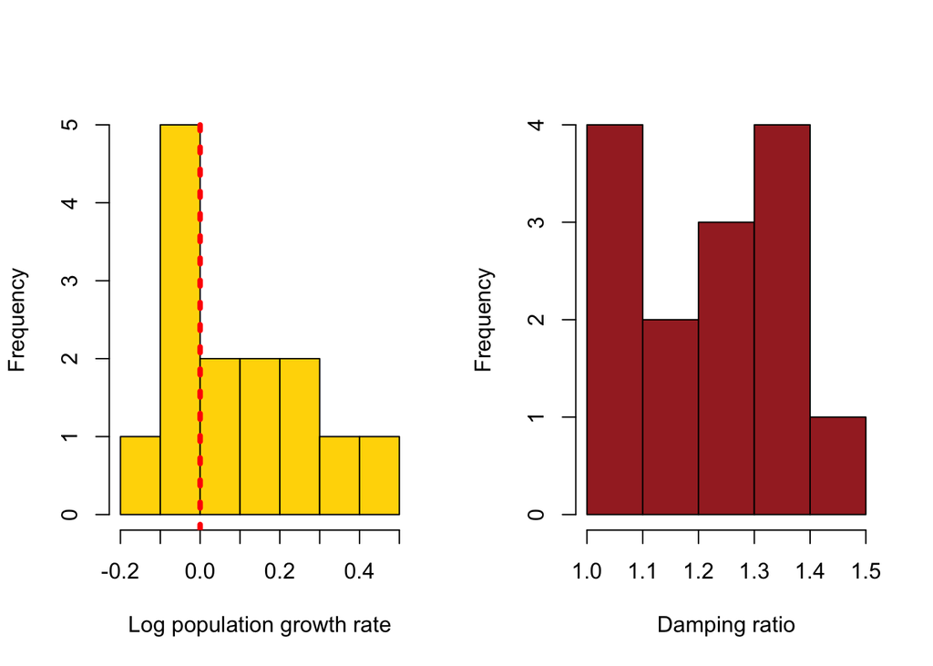

```r
par(mfrow = c(1,2))
hist(log(output$lambdas),
     xlab = "Log population growth rate",
     col = "gold", main = "")
abline(v=0,col = "red", lwd = 4, lty = 3)
hist(output$damps, xlab = "Damping ratio",
     col = "brown", main = "")
```